# MSDS Capstone

Gabby Hendrix

4/14/2021

###Data

```r
#Include required packages
library(dplyr)
library(tidyr)
library(caret)
library(e1071)
library(factoextra)
```

```r
library(ggplot2)
library(arules)
library(car)
library(graphics)
```

```r
#read in dataset
cities = read.csv("Final Capstone Dataset.csv")
```

###Data Preparation Remove any fields that will not be used for clustering from the dataset.

```r
clean_city = cities[,c(-2,-4,-5,-6,-7, -18)]
```

#### Transformations for Scale

In order to use a clustering analysis, like euclidean, that heavily relies on the distance between data points, we need to ensure that the scale of each variable lies in similar magnitudes. To check this, plots of a few of the features are shown below. The result shows that we have some variables in magnitudes of ten, hundreds, and thousands. Scaling will need to be performed on these variables to make them suitable for clustering.

Can see Below have tenth of degrees and thousands and millions in the same dataset

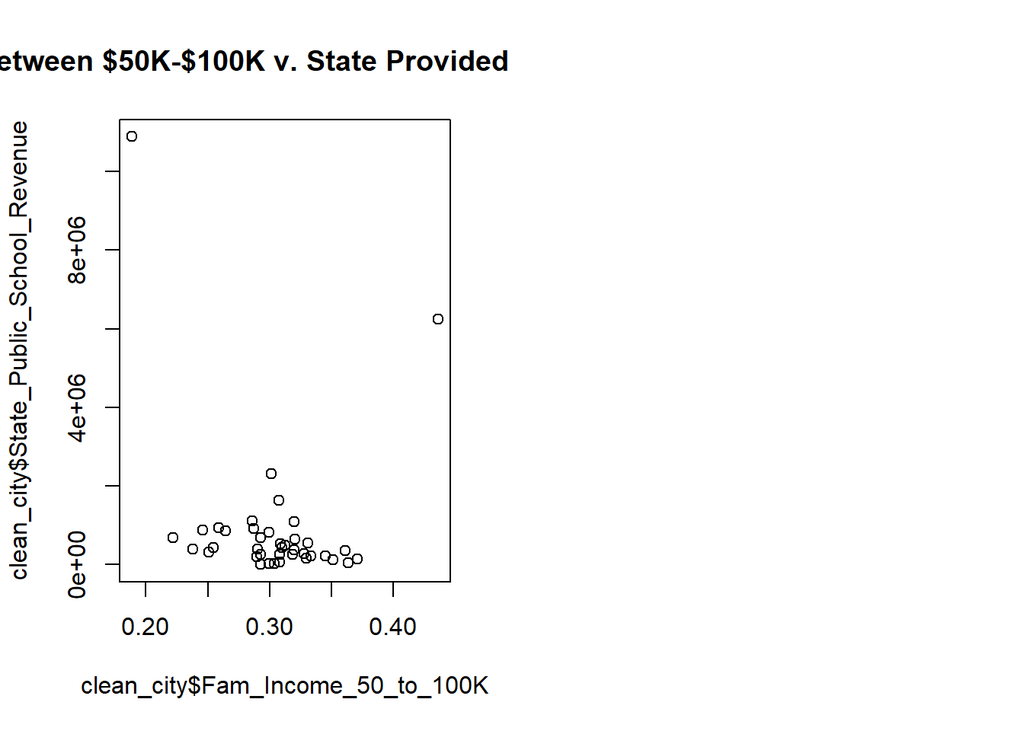

```r
#look at scale of the numeric features, scaling will be needed
par(mfrow=c(1,2))
plot(clean_city$Fam_Income_50_to_100K, clean_city$State_Public_School_Revenue, main="% of Families Income Between $50K-$100K v. State Provided Revenue for Public Schools")
```

##Data Analysis & Modelling ###Principal Components Analysis (PCA) The first step in the analysis will be to use PCA to determine which features are similar and dissimilar to each other. SNot only does PCA help to reduce the number of features we work with, it more importantly, enables us to determine which features provide new and unique information to our clustering model and are therefore identified as the most important features to base our clustering model around.

*Note: PCA can only be performed on numeric features, so only numeric features in our data set will be used for clustering moving forward. In this case all variables are numeric.*

```r
#remove the label and ID columns from the dataset
cleancity_df <- clean_city[, c(-1, -2)]

pc.info = prcomp(cleancity_df,center=T,scale=T)
summary(pc.info)
```

```
## Importance of components:
##                           PC1    PC2    PC3     PC4    PC5     PC6     PC7
## Standard deviation     4.5127 3.2702 3.1983 2.11345 2.0513 1.90882 1.79507
## Proportion of Variance 0.2715 0.1426 0.1364 0.05956 0.0561 0.04858 0.04296
## Cumulative Proportion  0.2715 0.4141 0.5505 0.61006 0.6662 0.71474 0.75771
##                            PC8     PC9    PC10    PC11    PC12    PC13    PC14
## Standard deviation     1.60968 1.53608 1.31405 1.24486 1.23662 1.12398 1.03101
## Proportion of Variance 0.03455 0.03146 0.02302 0.02066 0.02039 0.01684 0.01417
## Cumulative Proportion  0.79226 0.82372 0.84674 0.86740 0.88779 0.90464 0.91881
##                           PC15    PC16    PC17    PC18    PC19    PC20    PC21
## Standard deviation     0.96255 0.94599 0.78810 0.78207 0.71363 0.70227 0.59896
## Proportion of Variance 0.01235 0.01193 0.00828 0.00816 0.00679 0.00658 0.00478
## Cumulative Proportion  0.93116 0.94309 0.95138 0.95953 0.96632 0.97290 0.97768
##                           PC22    PC23    PC24    PC25   PC26    PC27    PC28
## Standard deviation     0.54507 0.46565 0.44842 0.41474 0.3869 0.36590 0.31341
## Proportion of Variance 0.00396 0.00289 0.00268 0.00229 0.0020 0.00179 0.00131
## Cumulative Proportion  0.98164 0.98453 0.98721 0.98951 0.9915 0.99329 0.99460
##                          PC29    PC30    PC31    PC32    PC33    PC34    PC35
## Standard deviation     0.2745 0.26912 0.23334 0.23073 0.21685 0.19567 0.14123
## Proportion of Variance 0.0010 0.00097 0.00073 0.00071 0.00063 0.00051 0.00027
## Cumulative Proportion  0.9956 0.99657 0.99729 0.99800 0.99863 0.99914 0.99941
##                           PC36    PC37    PC38    PC39      PC40
## Standard deviation     0.12921 0.12432 0.09199 0.06192 2.004e-15
## Proportion of Variance 0.00022 0.00021 0.00011 0.00005 0.000e+00
## Cumulative Proportion  0.99963 0.99984 0.99995 1.00000 1.000e+00
```

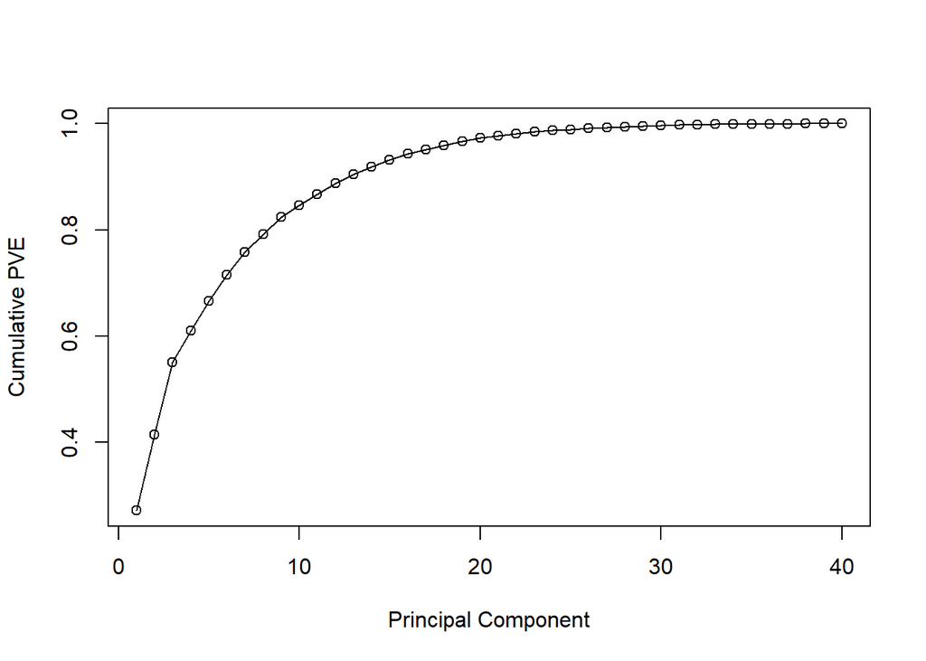

```r
vjs = pc.info$sdev^2
pve = vjs/sum(vjs)

plot(cumsum(pve), type = "o", ylab="Cumulative PVE", xlab="Principal Component")
```

Reviewing the loadings for the fist 9 PC’s, which provide 80% of the information in the data, we see the following characteristics are high contributors to each PC:

PC1 (Positive) - Business and Employment Fields: Number of Jobs created by existing businesses within the year (JOB_CREATION_BIRTHS), Number of new business openings (ESTABS_ENTRY), Total Job creation by any means (JOB_CREATION), Total Number of Jobs lost (JOB_DESTRUCTION), number of jobs lost at businesses that are remaining open (JOB_DESTRUCTION_CONTINUERS), Number of businesses that closed in the year (ESTABS_EXIT), N Umber of jobs lost to businesses closing (FIRMDEATH_EMP and JOB_DESTRUCTION_DEATHS), Count of Businesses in the city (ESTAB and FIRM)

PC1 (Negative) - Income: Fam_Income_25_to_50K, Fam_Income_Under_25k, Fam_Income_50_to_1000K

Consoldated the first 6 PCs into the economic categories, resulting in 40 variables selected by PCA (70% of information):

+Jobs: estabs estabs_entry estabs_exit job_creation job_creation_births job_creation_continuers job_destruction job_destruction_continuers job_destruction_deaths net_job_creation_rate

+Health: COPD Diabetes Heart_Disease_Age_35_to_64 High_Blood_Pressure Leisure_Time_Exercise Obesity Poor_Mental_Health Poor_Physical_Health Regular_Dental_Cleanings Stroke_Age_35_to_64 Stroke_Age_65_Up

+Income: Average_Childcare_Expense Estimated_city_number_of_relevant_children_5_to_17_years_old_in_poverty_who_are_related_to_the_householder Estimated_City_Population_5.17 Estimated_City_Total_Population Fam_Income_25_to_50K Fam_Income_Over_100k Fam_Income_Under_25k Homeowners Perct_SNAP_Recipients_July_17 Public_Housing Renters Wage_Based_Salary Welfare

+Public School System Local_Public_School_Revenue Prct_of_US_Total_School_Expenditure_ Public_School_Teacher_Salary_Expenses Public_School_Total_Salary_Expenses Total_Public_School_Expediture Total_Public_School_Reveune

###PCA1 and PCA2

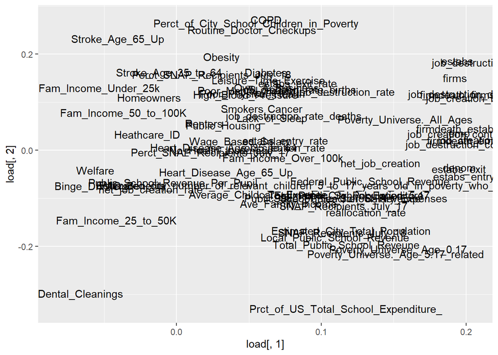

```r
#examine the loadings for PCA 1 and 2
load = pc.info$rotation
load = as.data.frame(load)

ggplot(load, aes(x = load[, 1], y = load[,2], label = rownames(load))) +
  geom_text(position=position_jitter(width=0.0,height=0.15))
```

Really Messy - Need to clean up to focus on the higher correlated variables. For PC 1 that is less than -0.06 and greater than 0.15. For PC2 that is less than -0.2 and greater than 0.2.

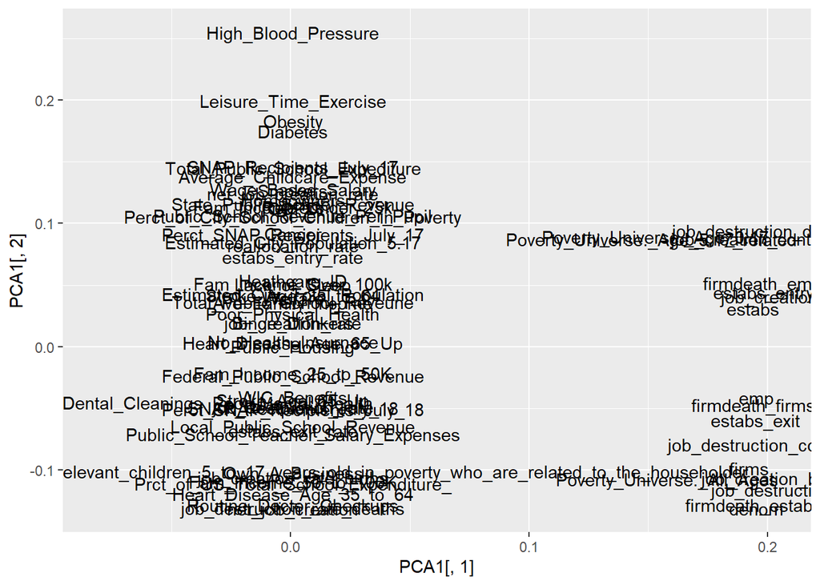

```r
PCA1 <- load[,c(1,2)]
PCA1$PC1[PCA1$PC1 > -0.06 & PCA1$PC1 < 0.15] <- 0.001
PCA1$PC2[PCA1$PC2 > -0.2 & PCA1$PC2 < 0.2] <- 0.001

#makes a data frame that is easy for me to read
PCA1ForMe <- load[,c(1,2)]
PCA1ForMe$PC1[PCA1ForMe$PC1 > -0.05 & PCA1ForMe$PC1 < 0.18] <- ""
PCA1ForMe$PC2[PCA1ForMe$PC2 > -0.18 & PCA1ForMe$PC2 < 0.18] <- ""

ggplot(PCA1, aes(x = PCA1[, 1], y = PCA1[,2], label = rownames(PCA1))) +
  geom_text(position=position_jitter(width=0.0,height=0.15))
```

###PCA3 and PCA4

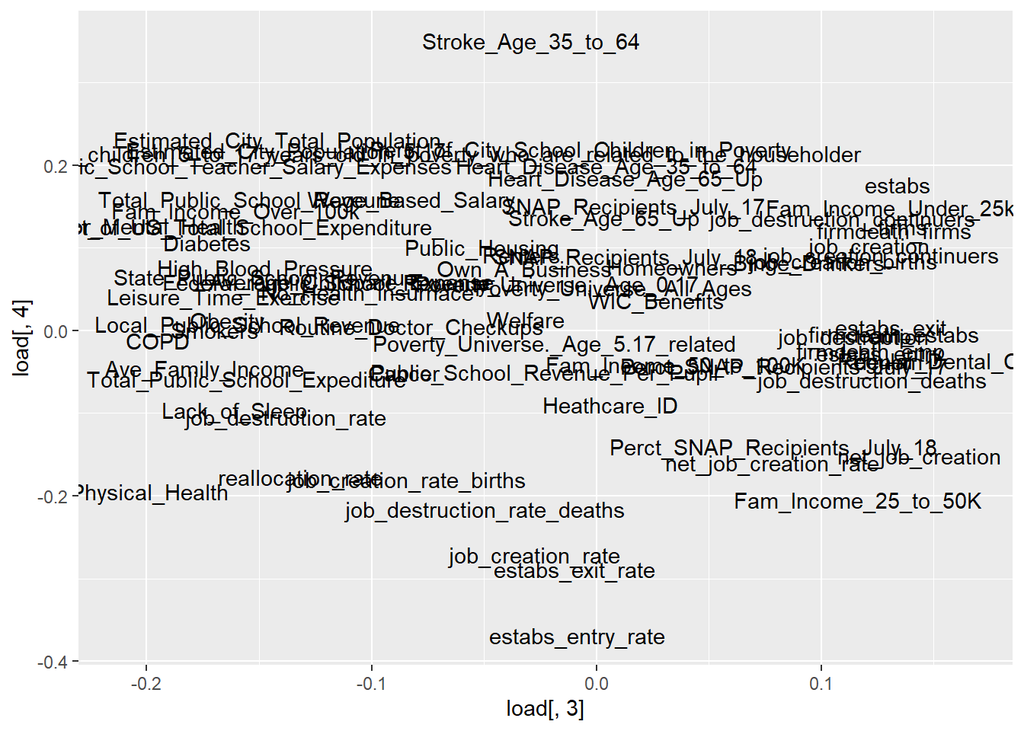

```r
#examine the loadings for PCA 3 and 4
load = pc.info$rotation
load = as.data.frame(load)

ggplot(load, aes(x = load[, 3], y = load[ ,4], label = rownames(load))) +
  geom_text(position=position_jitter(width=0.0,height=0.15))
```

Really Messy - Need to clean up to focus on the higher correlated variables. For PC 3 that is less than -0.15 and greater than 0.15. For PC4 that is less than -0.2 and greater than 0.3.

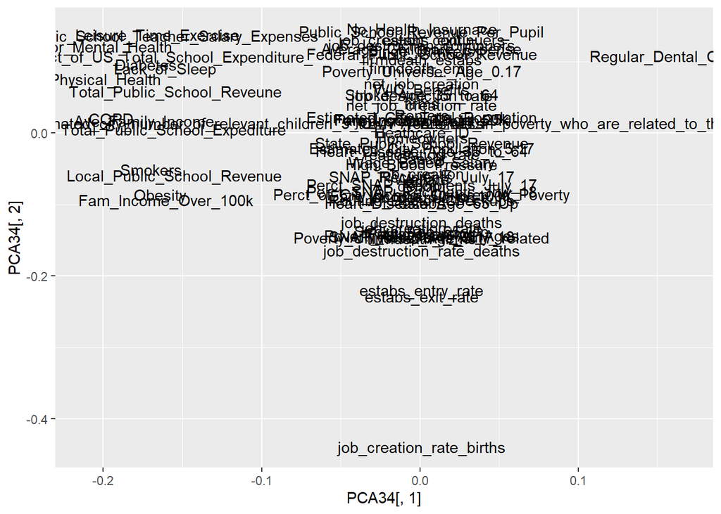

```r
PCA34 <- load[,c(3,4)]
PCA34$PC3[PCA34$PC3 > -0.15 & PCA34$PC3 < 0.15] <- 0.001
PCA34$PC4[PCA34$PC4 > -0.2 & PCA34$PC4 < 0.3] <- 0.001

#makes a data frame that is easy for me to read
PCA34ForMe <- load[,c(3,4)]
PCA34ForMe$PC3[PCA34ForMe$PC3 > -0.18 & PCA34ForMe$PC3 < 0.12] <- ""
PCA34ForMe$PC4[PCA34ForMe$PC4 > -0.18 & PCA34ForMe$PC4 < 0.20] <- ""

ggplot(PCA34, aes(x = PCA34[, 1], y = PCA34[,2], label = rownames(PCA34))) +
  geom_text(position=position_jitter(width=0.0,height=0.15))
```

###PCA5 and PCA6

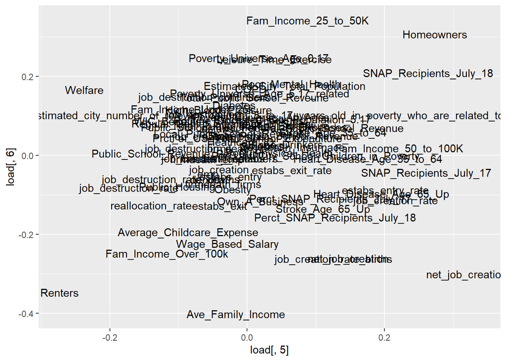

```r
#examine the loadings for PCA 5 and 6
load = pc.info$rotation
load = as.data.frame(load)

ggplot(load, aes(x = load[, 5], y = load[ ,6], label = rownames(load))) +
  geom_text(position=position_jitter(width=0.0,height=0.15))
```

Really Messy - Need to clean up to focus on the higher correlated variables. For PC5 that is less than -0.2 and greater than 0.2. For PC6 that is less than -0.2 and greater than 0.2.

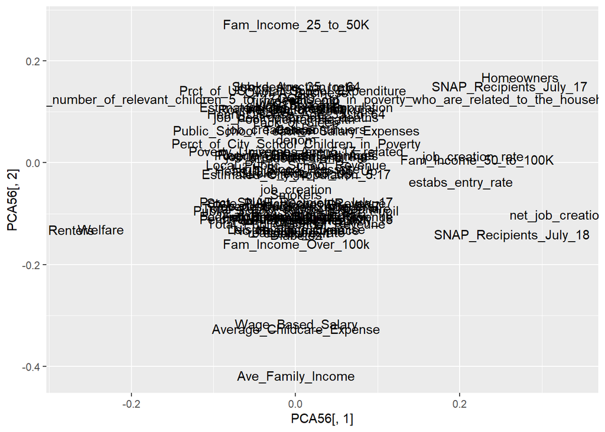

```r
PCA56 <- load[,c(5,6)]
PCA56$PC5[PCA56$PC5 > -0.2 & PCA56$PC5 < 0.2] <- 0.001
PCA56$PC6[PCA56$PC6 > -0.2 & PCA56$PC6 < 0.2] <- 0.001

#makes a data frame that is easy for me to read
PCA56ForMe <- load[,c(5,6)]
PCA56ForMe$PC5[PCA56ForMe$PC5 > -0.2 & PCA56ForMe$PC5 < 0.2] <- ""
PCA56ForMe$PC6[PCA56ForMe$PC6 > -0.2 & PCA56ForMe$PC6 < 0.2] <- ""

ggplot(PCA56, aes(x = PCA56[, 1], y = PCA56[,2], label = rownames(PCA56))) +
  geom_text(position=position_jitter(width=0.0,height=0.15))
```

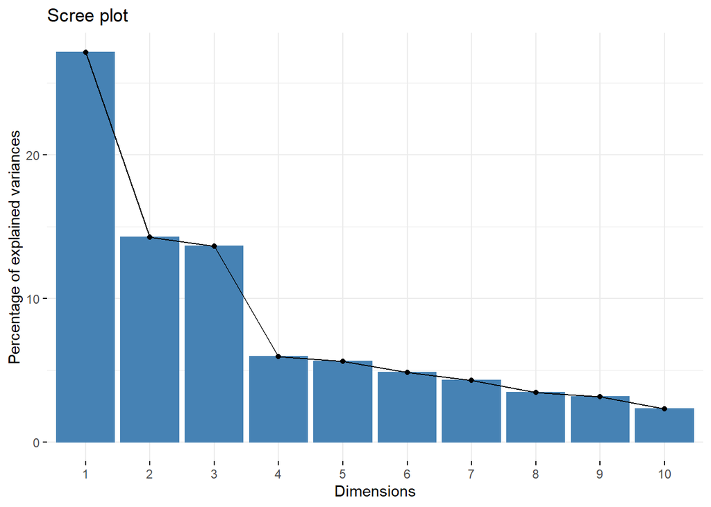

```r
fviz_eig(pc.info)
```

The biplot below confirms are findings from our inital look at the PCA loadings. We see that the Business and Employment Data is the most important (followed by School Data almost equally, followed by health), will definitely need to be included in the clustering analysis in the next phases.

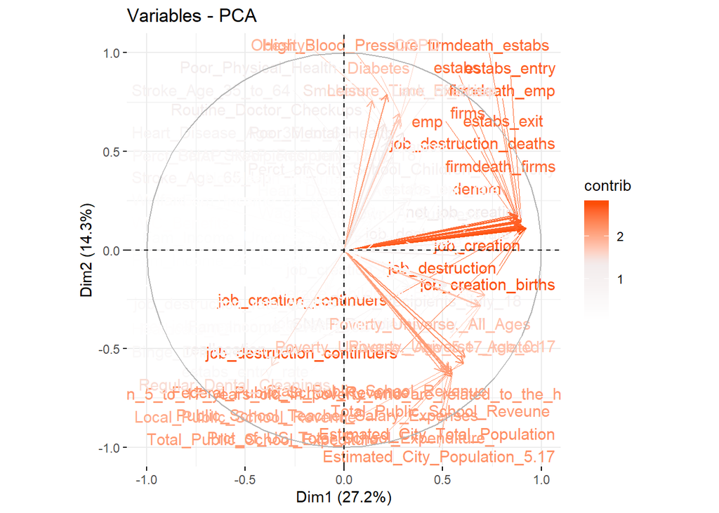

```r
#create the biplot with rowname filters
fviz_pca_var(pc.info,
             col.var = "contrib", # Color by contributions to the PC
             gradient.cols = c("#ffffff", "#f2ebeb", "#FC4E07"),
             repel = TRUE     # Avoid text overlapping
             )
```

###Clustering ####Pre-assessment of Data Distribution

The PCA results points to Employment, BUsiness, and Public School Data as the most imporant feaures in the data set, in terms of providing information; therefore, these variables will be used to help us cluster our data into groups. But what should expect these groups to look like?

To help determine this, let’s take a look at the distribution of a few of these employment and business stats. The original dataset has been grouped by segregated or integrated. This will allow us to see how the job stats are distributed amoungst the most and least segregated cities.

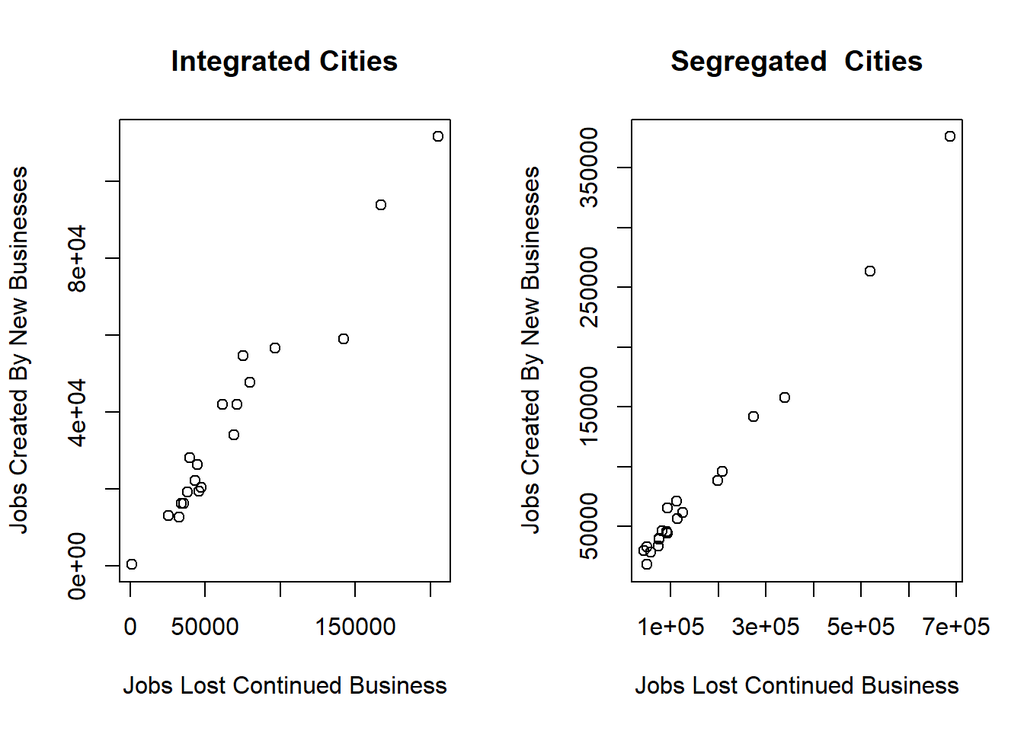

```r
i_jobs_data <- clean_city[clean_city$Status == "I",]
s_jobs_data <- clean_city[clean_city$Status == "S",]

par(mfrow=c(1,2))

plot(i_jobs_data$job_destruction_continuers,i_jobs_data$job_creation_births, ylab = "Jobs Created By New Businesses", xlab = "Jobs Lost Continued Business", main = "Integrated Cities")
#text(i_jobs_data$job_destruction_continuers,i_jobs_data$job_creation_births,labels=i_jobs_data$`ï..City`, cex=0.7, font=1)

plot(s_jobs_data$job_destruction_continuers,s_jobs_data$job_creation_births, ylab = "Jobs Created By New Businesses", xlab = "Jobs Lost Continued Business", main = "Segregated  Cities")
```

```r
#text(s_jobs_data$job_destruction_continuers,s_jobs_data$job_creation_births,labels=s_jobs_data$`ï..City`, cex=0.7, font=1)
```

Boxplots to further understand current state

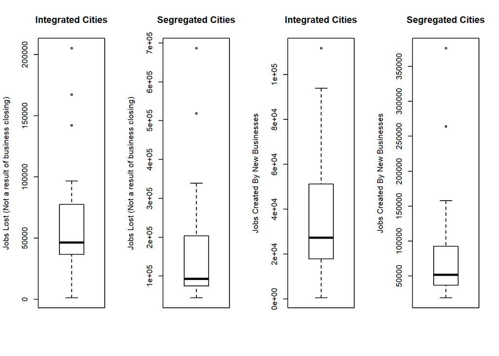

```r
par(mfrow=c(1,4))
boxplot(i_jobs_data$job_destruction_continuers, main = "Integrated Cities", ylab = "Jobs Lost (Not a result of business closing)")
boxplot(s_jobs_data$job_destruction_continuers, main = "Segregated Cities", ylab = "Jobs Lost (Not a result of business closing)")

boxplot(i_jobs_data$job_creation_births, main = "Integrated Cities", ylab = "Jobs Created By New Businesses")
boxplot(s_jobs_data$job_creation_births, main = "Segregated Cities", ylab = "Jobs Created By New Businesses")
```

Job Destruction Cont - Integrated: Median = 47k Job Destruction Cont - Segrated: Median = 92k

Job Creation Births - Integrated: Median = 28k Job Creation Births - Segrated: Median = 50k

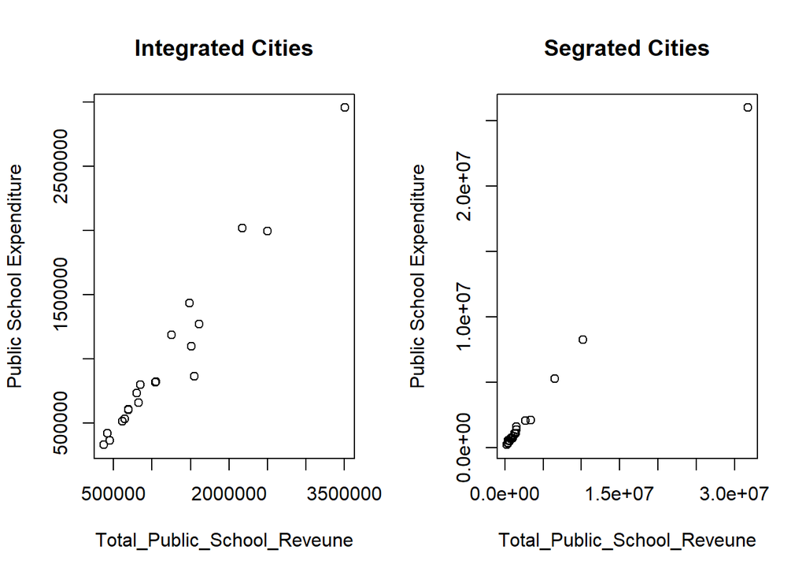

```r
par(mfrow=c(1,2))

plot(i_jobs_data$Total_Public_School_Reveune,i_jobs_data$Total_Public_School_Expediture, ylab = "Public School Expenditure", xlab = "Total_Public_School_Reveune", main = "Integrated Cities")

plot(s_jobs_data$Total_Public_School_Reveune,s_jobs_data$Total_Public_School_Expediture, ylab = "Public School Expenditure", xlab = "Total_Public_School_Reveune", main = "Segrated Cities")
```

Boxplots to further understand current state

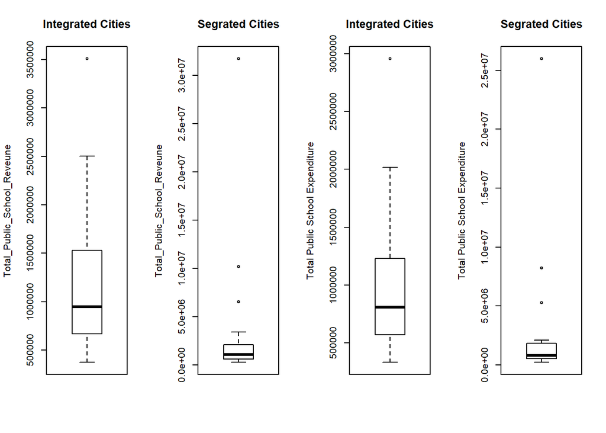

```r
par(mfrow=c(1,4))
boxplot(i_jobs_data$Total_Public_School_Reveune, main = "Integrated Cities", ylab = "Total_Public_School_Reveune")
boxplot(s_jobs_data$Total_Public_School_Reveune, main = "Segrated Cities", ylab = "Total_Public_School_Reveune")

boxplot(i_jobs_data$Total_Public_School_Expediture, main = "Integrated Cities", ylab = "Total Public School Expenditure")
boxplot(s_jobs_data$Total_Public_School_Expediture, main = "Segrated Cities", ylab = "Total Public School Expenditure")
```

Total_Public_School_Expediture - Integrated: Median = 800K Total_Public_School_Expediture - Segrated: Median = 800K

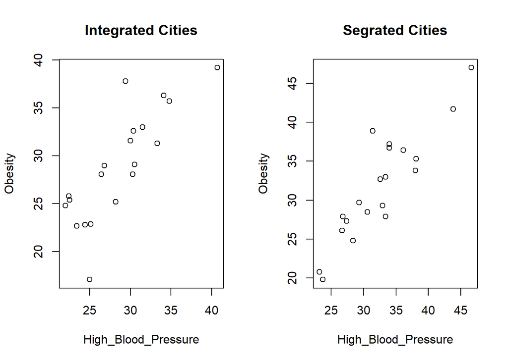

```r
par(mfrow=c(1,2))
plot(i_jobs_data$High_Blood_Pressure,i_jobs_data$Obesity, ylab = "Obesity", xlab = "High_Blood_Pressure", main = "Integrated Cities")
plot(s_jobs_data$High_Blood_Pressure,s_jobs_data$Obesity, ylab = "Obesity", xlab = "High_Blood_Pressure", main = "Segrated Cities")
```

Boxplots to further understand current state

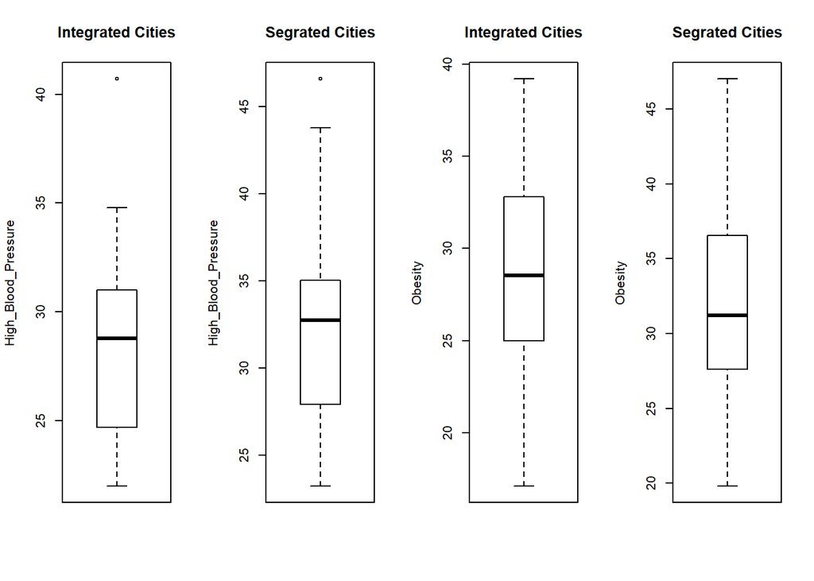

```r
par(mfrow=c(1,4))
boxplot(i_jobs_data$High_Blood_Pressure, main = "Integrated Cities", ylab = "High_Blood_Pressure")
boxplot(s_jobs_data$High_Blood_Pressure, main = "Segrated Cities", ylab = "High_Blood_Pressure")

boxplot(i_jobs_data$Obesity, main = "Integrated Cities", ylab = "Obesity")
boxplot(s_jobs_data$Obesity, main = "Segrated Cities", ylab = "Obesity")
```

High Blood Pressure - Integrated: Median = 28.8 High Blood Pressure - Segrated: Median = 32.75

Obesity - Integrated: Median = 28.5 Obesity - Segrated: Median = 31.2

####Euclidean with Complete Linkage Summarize Findings

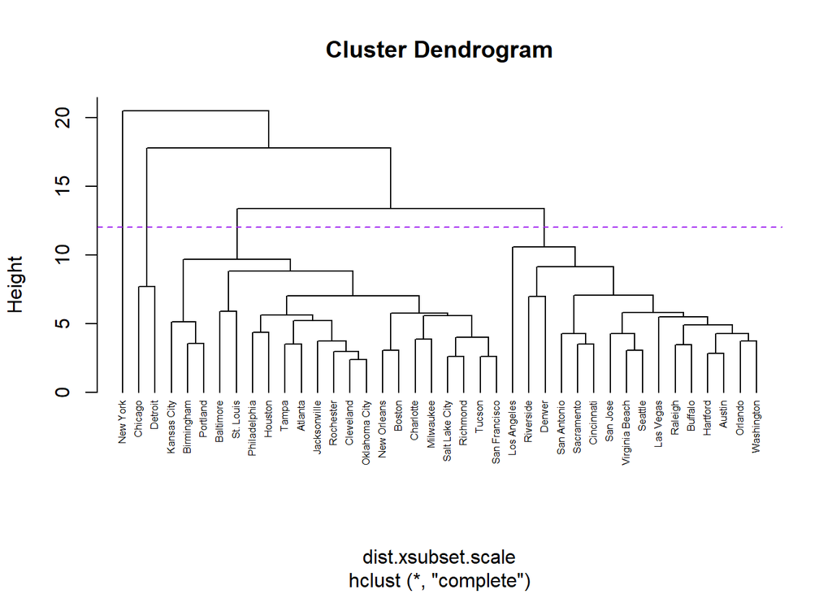

```r
#chosing only variables identified by PCA and not any identifiers or labels
xsubset = clean_city[,c(3, 4, 9, 11, 12, 13, 14, 16, 17, 20, 23, 25, 27, 28, 29, 32, 33, 34, 38, 47, 49, 50, 51, 55, 60, 61, 62, 66, 69, 70, 71, 72, 73, 74, 75, 76, 77)]
xsubset.scale = scale(xsubset)

############ fitting hierarchical models - complete  ############
dist.xsubset.scale = dist(xsubset.scale, method="euclidean")
hc.complete = hclust(dist.xsubset.scale,method="complete") #furthest distance btwn cluster

#Plot Dendrogram
par(mfrow=c(1,1))
plot(hc.complete,cex=0.5, labels = clean_city$`ï..City`, hang = -1)
abline(h=c(12),col=c("purple","red","blue"),lty=2)  # drawing line where the biggest two clusters separate
```